# Summaries

2019-03-18

```r
library(tidyverse)
library(nycflights13)
```

dplyr summarise() function can be used to calculate counts and proportions of logical values: sum(x > 10), mean(y == 0).

When used with numeric functions, TRUE is converted to 1 and FALSE to 0.

> This makes sum() and mean() very useful: sum(x) gives the number of TRUEs in x, and mean(x) gives the proportion.

### Exercises

1. Using nycflights13 “flights” dataset, brainstorm at least 5 different ways to assess the typical delay characteristics of a group of flights.

```r
flights
```

```
## # A tibble: 336,776 x 19
##     year month   day dep_time sched_dep_time dep_delay arr_time
##    <int> <int> <int>    <int>          <int>     <dbl>    <int>
##  1  2013     1     1      517            515         2      830
##  2  2013     1     1      533            529         4      850
##  3  2013     1     1      542            540         2      923
##  4  2013     1     1      544            545        -1     1004
##  5  2013     1     1      554            600        -6      812
##  6  2013     1     1      554            558        -4      740
##  7  2013     1     1      555            600        -5      913
##  8  2013     1     1      557            600        -3      709
##  9  2013     1     1      557            600        -3      838
## 10  2013     1     1      558            600        -2      753
## # … with 336,766 more rows, and 12 more variables: sched_arr_time <int>,
## #   arr_delay <dbl>, carrier <chr>, flight <int>, tailnum <chr>,
## #   origin <chr>, dest <chr>, air_time <dbl>, distance <dbl>, hour <dbl>,
## #   minute <dbl>, time_hour <dttm>
```

Consider the following scenarios:

- A flight is 15 minutes early 50% of the time, and 15 minutes late 50% of the time.

```r
flights %>%
  group_by(flight) %>%
  summarize(n = n(),
            early15 = mean(arr_delay <= -15, na.rm = TRUE),
            late15 = mean(arr_delay >= 15, na.rm =TRUE)) %>%
  filter(early15 == 0.5 & late15 == 0.5)
```

```
## # A tibble: 21 x 4
##    flight     n early15 late15
##     <int> <int>   <dbl>  <dbl>
##  1    107     2     0.5    0.5
##  2   2072     2     0.5    0.5
##  3   2366     2     0.5    0.5
##  4   2500     2     0.5    0.5
##  5   2552     2     0.5    0.5
##  6   3495     2     0.5    0.5
##  7   3505     3     0.5    0.5
##  8   3518     2     0.5    0.5
##  9   3544     2     0.5    0.5
## 10   3651     2     0.5    0.5
## # … with 11 more rows
```

- A flight is always 10 minutes late.

```r
flights %>%
  group_by(flight) %>%
  summarize(n = n(),
            late10 = mean(arr_delay >= 10, na.rm = TRUE)) %>%
  filter(late10 == 1)
```

```
## # A tibble: 98 x 3
##    flight     n late10
##     <int> <int>  <dbl>
##  1     94     1      1
##  2    730     2      1
##  3    974     1      1
##  4   1084     3      1
##  5   1226     1      1
##  6   1510     1      1
##  7   1514     1      1
##  8   1859     1      1
##  9   1868     2      1
## 10   1998     2      1
## # … with 88 more rows
```

- A flight is 30 minutes early 50% of the time, and 30 minutes late 50% of the time.

```r
flights %>%
  group_by(flight) %>%
  summarize(n = n(),
            early30 = mean(arr_delay <= -30, na.rm = TRUE),
            late30 = mean(arr_delay >= 30, na.rm =TRUE)) %>%
  filter(early30 == 0.5 & late30 == 0.5)
```

```
## # A tibble: 3 x 4
##   flight     n early30 late30
##    <int> <int>   <dbl>  <dbl>
## 1   3651     2     0.5    0.5
## 2   3916     2     0.5    0.5
## 3   3951     2     0.5    0.5
```

- 99% of the time a flight is on time. 1% of the time it’s 2 hours late.

```r
flights %>%
  group_by(flight) %>%
  summarize(n = n(),
            ontime = mean(arr_delay == 0, na.rm = TRUE),
            late120 = mean(arr_delay >= 120, na.rm =TRUE)) %>%
  filter(ontime == 0.99 & late120 == 0.01)
```

```
## # A tibble: 0 x 4
## # … with 4 variables: flight <int>, n <int>, ontime <dbl>, late120 <dbl>
```

- Which is more important: arrival delay or departure delay? Saabumise hilinemine, sest ei pruugi jõuda järgmisele lennule vms.
2. Come up with another approach that will give you the same output as not_cancelled %>% count(dest) and not_cancelled %>% count(tailnum, wt = distance) (without using count()).

```r
not_cancelled <- flights %>%
  filter(!is.na(dep_delay), !is.na(arr_delay))
```

```r
not_cancelled %>% count(dest)
```

```
## # A tibble: 104 x 2
##    dest      n
##    <chr> <int>
##  1 ABQ     254
##  2 ACK     264
##  3 ALB     418
##  4 ANC       8
##  5 ATL   16837
##  6 AUS    2411
##  7 AVL     261
##  8 BDL     412
##  9 BGR     358
## 10 BHM     269
## # … with 94 more rows
```

```r
not_cancelled %>%
  group_by(dest) %>%
  summarise(n = length(dest))
```

```
## # A tibble: 104 x 2
##    dest      n
##    <chr> <int>
##  1 ABQ     254
##  2 ACK     264
##  3 ALB     418
##  4 ANC       8
##  5 ATL   16837
##  6 AUS    2411
##  7 AVL     261
##  8 BDL     412
##  9 BGR     358
## 10 BHM     269
## # … with 94 more rows
```

```r
not_cancelled %>% count(tailnum, wt = distance)
```

```
## # A tibble: 4,037 x 2
##    tailnum      n
##    <chr>    <dbl>
##  1 D942DN    3418
##  2 N0EGMQ  239143
##  3 N10156  109664
##  4 N102UW   25722
##  5 N103US   24619
##  6 N104UW   24616
##  7 N10575  139903
##  8 N105UW   23618
##  9 N107US   21677
## 10 N108UW   32070
## # … with 4,027 more rows
```

```r
not_cancelled %>%
  group_by(tailnum) %>%
  summarise(n = sum(distance))
```

```
## # A tibble: 4,037 x 2
##    tailnum      n
##    <chr>    <dbl>
##  1 D942DN    3418
##  2 N0EGMQ  239143
##  3 N10156  109664
##  4 N102UW   25722
##  5 N103US   24619
##  6 N104UW   24616
##  7 N10575  139903
##  8 N105UW   23618
##  9 N107US   21677
## 10 N108UW   32070
## # … with 4,027 more rows
```

3. Our definition of cancelled flights (is.na(dep_delay) | is.na(arr_delay) ) is slightly suboptimal. Why? Which is the most important column?

Juhul kui lend läheb küll välja, kuid ei saabu sihtkohta, ei ole ta tühistatud (näiteks suunati mingil põhjusel mujale ümber). Seega on dep_delay tühistamise määramiseks olulisem.

4. Look at the number of cancelled flights per day. Is there a pattern? Is the proportion of cancelled flights related to the average delay?

```r
cancelled_flights <-
  flights %>%
  mutate(cancelled = (is.na(dep_delay))) %>%
  group_by(year, month, day) %>%
  summarise(
    prop_cancelled = mean(cancelled),
    avg_delay = mean(dep_delay, na.rm = TRUE)
  )
cancelled_flights
```

```
## # A tibble: 365 x 5
## # Groups:   year, month [12]
##     year month   day prop_cancelled avg_delay
##    <int> <int> <int>          <dbl>     <dbl>
##  1  2013     1     1        0.00475     11.5
##  2  2013     1     2        0.00848     13.9
##  3  2013     1     3        0.0109      11.0
##  4  2013     1     4        0.00656      8.95
##  5  2013     1     5        0.00417      5.73
##  6  2013     1     6        0.00120      7.15
##  7  2013     1     7        0.00322      5.42
##  8  2013     1     8        0.00445      2.55
##  9  2013     1     9        0.00554      2.28
## 10  2013     1    10        0.00322      2.84
## # … with 355 more rows
```

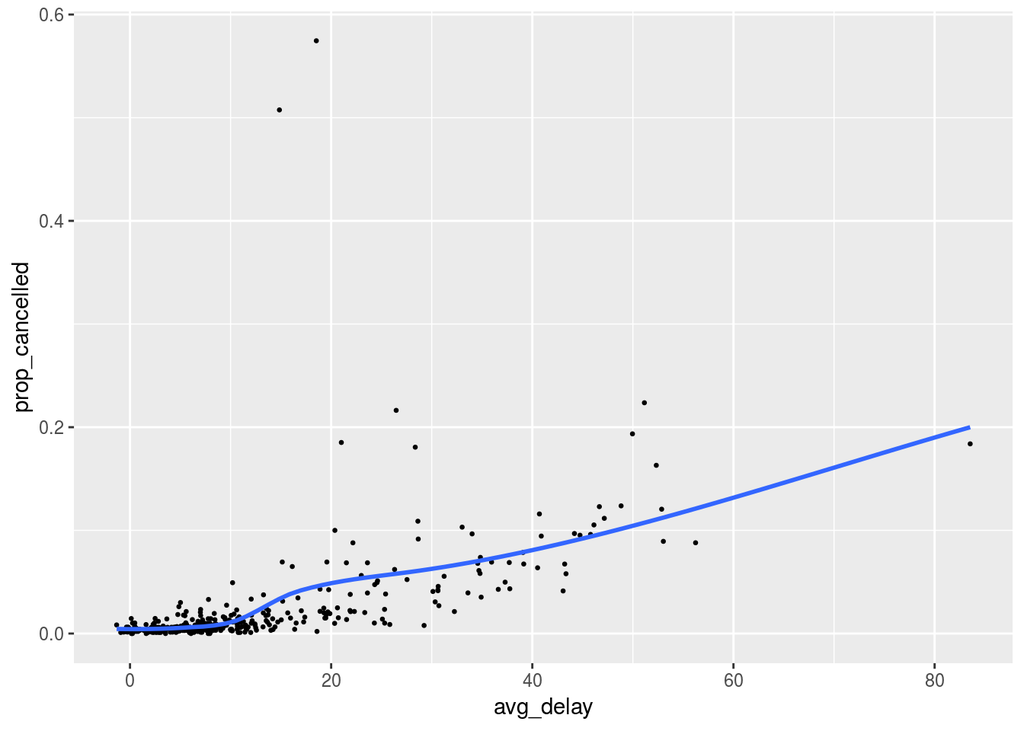

```r
ggplot(cancelled_flights, aes(x = avg_delay, prop_cancelled)) +
  geom_point(size=0.5) +
  geom_smooth(se = FALSE)
```

Päevadel, kui on rohkem tühistatud lende, on ka suuremad hilinemised.

5. Which carrier has the worst delays? Challenge: can you disentangle the effects of bad airports vs. bad carriers? Why/why not? (Hint: think about flights %>% group_by(carrier, dest) %>% summarise(n()))

```r
flights %>%
  group_by(carrier) %>%
  summarise(arr_delay = mean(arr_delay, na.rm = TRUE)) %>%
  arrange(desc(arr_delay))
```

```
## # A tibble: 16 x 2
##    carrier arr_delay
##    <chr>       <dbl>
##  1 F9         21.9
##  2 FL         20.1
##  3 EV         15.8
##  4 YV         15.6
##  5 OO         11.9
##  6 MQ         10.8
##  7 WN          9.65
##  8 B6          9.46
##  9 9E          7.38
## 10 UA          3.56
## 11 US          2.13
## 12 VX          1.76
## 13 DL          1.64
## 14 AA          0.364
## 15 HA         -6.92
## 16 AS         -9.93
```

6. What does the sort argument to count() do. When might you use it?

Sorteerib loendatava suuruse kahanevas järjekorras. Arrange asemel.

```r
flights %>%
  count(flight, sort = TRUE)
```

```
## # A tibble: 3,844 x 2
##    flight     n
##     <int> <int>
##  1     15   968
##  2     27   898
##  3    181   882
##  4    301   871
##  5    161   786
##  6    695   782
##  7   1109   716
##  8    745   711
##  9    359   709
## 10      1   701
## # … with 3,834 more rows
```